# Automatic gating on ADT data

To explore the compatibility of automatic gating methods with SECANT, we applied FLOCK[1] and flowMeans[2], which are popular automatic flow cytometry gating methods recommended by several review papers[3,4], on the 10x10k PBMC ADT dataset. After applying these gating methods, we also used linear discriminant analysis(LDA) to estimate the probability that each cell belongs to each cluster and then identify the cells that cannot be confidently classified based only on ADT data. Both FLOCK and flowMeans can give similar gating results as manual gating, but flowMeans relies more heavily on manual tuning of the parameters, and thus requires more biological background knowledge to guide the tuning process. On the other hand, FLOCK can give satisfactory results without much manual tuning, and can be applied without any prior biological background knowledge. Although the automatic gating cannot perfectly replicate the manual gating results, we demonstrate its potential to be a good substitution for the manual gating process in SECANT, especially when background biological knowledge is lacking.

In the following sections, we first illustrate the application of FLOCK and LDA on the 10x10k PBMC dataset, and then we provide a generalized function that takes the FLOCK analysis result as input and then outputs a gating result in which uncertain cells are identified.

# FLOCK + LDA for PBMC data

## Loading data

```r
flock = read_csv("../Data/flock_result_auto.csv")
flock_centroid = read_csv("../Data/flock_centroid_auto.csv")
```

These two datasets are directly from the FLOCK output. The FLOCK algorithm is implemented in the Immunology Database and Analysis Portal (ImmPort; http://www.immport.org), and the analysis is done with one click without any tuning. Although manual tuning is possible, the results used here is given by the completely automatic process. The first dataset contains the original ADT data for all cells plus a column indicating the predicted population for each cell. The second dataset contains the ADT profile of the centroid of each population. The second dataset is shown below:

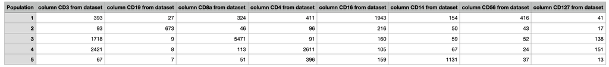

In this case, biological background knowledge is available, and we can match the predicted 5 populations to 5 types of cells:

- Population1: CD3- CD19- CD14- CD16+ (NK cells)
- Population2: CD3- CD19+ (B cells)
- Population3: CD3+ CD19- CD4- CD8a+ (CD8+ T cells)
- Population4: CD3+ CD19- CD4+ CD8a- (CD4+ T cells)
- Population5: CD3- CD19- CD14+ CD16- (CD14+ monocytes)

## Create uncertainty

Next, use linear discriminant analysis to create uncertainty. The dataset is randomly divided into 5 folds. For the cells in each fold, to predict their cell type identities(with uncertainties), cells from all the other folds are used as the training set for linear discriminant analysis, and the gating results by FLOCK will be used as the true labels. This analysis outputs the predicted probability for each cell to belong to each population.

```r
set.seed(11)
nfolds = 5
flock = flock %>%
  mutate(Folds = createFolds(Population, k = nfolds, list = F)) %>%
  mutate(id = 1:nrow(.))

for (i in 1:nfolds) {
   lda.fit <- lda(Population ~ ., data = flock %>% filter(Folds != i) %>% dplyr::select(-id, -Folds))
   lda.pred = predict(lda.fit, newdata = flock %>% filter(Folds == i) %>% dplyr::select(-id, -Folds))
   pred_subset = flock %>%
     filter(Folds == i) %>%
     dplyr::select(id) %>%
     bind_cols(lda.pred$posterior %>% as_tibble())

   if (i == 1)
     pred = pred_subset
   else
     pred = bind_rows(pred, pred_subset)
 }

pred = pred %>%
  arrange(id) %>%
  dplyr::select(-id)
```

## Selection of cut-off values

The cut-off value is used to divide between “confident” and “unknown” cells. A cell that is predicted to have a probability greater than the cut-off value to belong to a population will be “confidently” labeled as a cell from that population; otherwise, the cell is labeled as “unknown”.

```r
load("~/FLOCK/Automatic Gating/Data/Truth_10X10k.rdata")
true_type = recode(true_type, `Dendritic cells` = "unknown", `CD16+ monocytes` = "unknown")


cut_off_sequence = seq(0.8,0.9999,0.0005)

out = data.frame(matrix(ncol=3,nrow=0, dimnames=list(NULL, c("cut_off","confident_cells", "Accuracy"))))

map_class = function(x){
  cell_types = c("NK cells", "B cells", "CD8+ T cells", "CD4+ T cells", "CD14+ monocytes")
  if (max(x) > cut_off)
    return(cell_types[which.max(x)])
  else
    return("unknown")
}
```

### Visualization

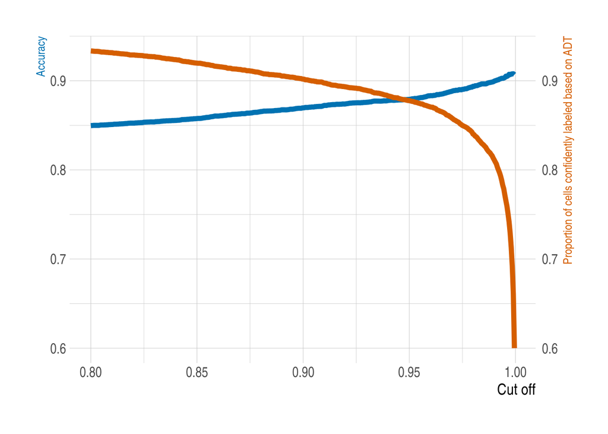

```r
k=1
for (i in cut_off_sequence) {
  cut_off = i
  flock_pred = flock %>%
  mutate(class = apply(pred, 1, map_class))
  comparison = tibble(true = true_type, pred = flock_pred$class)
  certain_comparison = comparison %>%
  filter(pred != 'unknown')

  out[k,1] = i
  out[k,2] = nrow(certain_comparison) / nrow(comparison)
  out[k,3] = sum(certain_comparison[,1]==certain_comparison[,2])/nrow(certain_comparison)
  k = k+1
}

coeff <- 1

accuracyColor <- "#0072B2"
countColor <- "#D55E00"

ggplot(out, aes(x=cut_off)) +

  geom_line( aes(y=Accuracy), size=2, color=accuracyColor) +
  geom_line( aes(y=confident_cells/coeff), size=2, color=countColor) +

  scale_y_continuous(

    # Features of the first axis
    name = "Accuracy",

    # Add a second axis and specify its features
    sec.axis = sec_axis(~.*coeff, name="Proportion of cells confidently labeled based on ADT")
  ) +
  scale_x_continuous(name = "Cut off") +
  theme_ipsum() +
  theme(
    axis.title.y = element_text(color = accuracyColor, size=10),
    axis.title.y.right = element_text(color = countColor, size=10),
    axis.title.x.bottom = element_text(size = 13)
  )
```

The accuracy reflects the consistency between the predicted cell type labels and the true cell type labels. Note that the manual gating results are used as the approximated truth. Before calculating the accuracy, cells that are predicted to be unknown are excluded, but cells that are truly unknown are not excluded. Note that cells that are truly unknown but are not predicted to be unknown are counted towards prediction errors. As expected, as the cut off value increases, the proportion of confidently labeled cells decreases but the accuracy increases.

## Example and visualizations

In the manual gating result, 16.3% of the cells are classified as unknown. To produce a similar proportion of unknown cells in our FLOCK + LDA prediction, we select cut off value to be 0.99, such that about 18.9% of the cells are predicted to be unknown:

```r
cut_off = 0.99

flock = flock %>%
  mutate(class = apply(pred, 1, map_class))

comparison = tibble(true = true_type, pred = flock$class)

head(comparison, 20) %>% knitr::kable()
```

| true | pred |
| --- | --- |
| CD14+ monocytes | CD14+ monocytes |
| unknown | unknown |
| CD14+ monocytes | CD14+ monocytes |
| NK cells | NK cells |
| NK cells | NK cells |
| unknown | CD14+ monocytes |
| unknown | CD14+ monocytes |
| CD14+ monocytes | CD14+ monocytes |
| CD4+ T cells | CD4+ T cells |
| CD4+ T cells | CD4+ T cells |
| CD4+ T cells | CD4+ T cells |
| CD4+ T cells | CD4+ T cells |
| CD4+ T cells | CD4+ T cells |
| B cells | B cells |
| CD8+ T cells | CD8+ T cells |
| unknown | NK cells |
| CD4+ T cells | CD4+ T cells |
| CD4+ T cells | CD4+ T cells |
| CD8+ T cells | CD8+ T cells |
| CD14+ monocytes | CD14+ monocytes |

```r
#exclude cells that are predicted to be unknown, keep the cells that are truly unknown, and calculate prediction accuracy
#cells that are truly unknown but are not predicticted to be unknown are counted towards prediction errors.
certain_comparison = comparison %>%
  filter(pred != 'unknown')
nrow(certain_comparison) / nrow(comparison) #proportion of cells that are predicted not to be unknown:
```

```
## [1] 0.8111888
```

```r
sum(certain_comparison[,1]==certain_comparison[,2])/nrow(certain_comparison) #Accuracy, i.e., proportion of cells that have consistent cell type labels in predicted results and manual gating results:
```

```
## [1] 0.8995298
```

We can also calculate prediction accuracy in a less conservative way, i.e., exclude cells that are either predicted to be unknown or truly unknown, and then calculate prediction accuracy:

```r
#exclude cells that are either predicted to be unknown or truly unknown, and calculate prediction accuracy
certain_comparison = comparison %>%
  filter(pred != 'unknown' & true != 'unknown')
nrow(certain_comparison) / nrow(comparison) #proportion of cells that are neither predicted to be unknown nor truly unknown:
```

```
## [1] 0.7378258
```

```r
sum(certain_comparison[,1]==certain_comparison[,2])/nrow(certain_comparison) #Accuracy, i.e., proportion of cells that have consistent cell type labels in predicted results and manual gating results:
```

```
## [1] 0.9889712
```

```r
adt = read_csv("../Data/adt.csv")

log_trans <- function(x){
  return(log(x+1))
}
adt_plot = map_df(adt,.f=log_trans)

adt_plot = adt_plot %>%
  mutate(class = flock$class)

CD3_CD19 = adt_plot %>%
  mutate(class = recode(class, `CD14+ monocytes` = "Other(CD14+ monocytes/NK cells)",`NK cells` = "Other(CD14+ monocytes/NK cells)", `CD4+ T cells` = "T cells", `CD8+ T cells` = "T cells")) %>%
  ggplot(aes(x = CD3_TotalSeqB, y = CD19_TotalSeqB, color = class)) + geom_point() + scale_color_manual(name='', breaks = c("B cells", "T cells","Other(CD14+ monocytes/NK cells)", "unknown"),
                        values=c("#E69F00","#56B4E9",
          "#C3D7A4", "#999999"))+ theme_test() +
    theme(legend.position = "top") +
  labs(
    x = "log(CD3+1)",
    y = "log(CD19+1)"
  )

CD4_CD8 = adt_plot  %>%
  mutate(class = recode(class, `B cells` = "Other(B cells/CD14+ monocytes/NK cells)",`NK cells` = "Other(B cells/CD14+ monocytes/NK cells)", `CD14+ monocytes` = "Other(B cells/CD14+ monocytes/NK cells)")) %>%
  ggplot(aes(x = CD4_TotalSeqB, y = CD8a_TotalSeqB, color = class)) + geom_point() + scale_color_manual(name='', breaks = c("CD4+ T cells", "CD8+ T cells", "Other(B cells/CD14+ monocytes/NK cells)", "unknown"),
                        values=c("#009E73","#F0E442",
          "#C3D7A4", "#999999"))+ theme_test() +
    theme(legend.position = "top") +
  labs(
    x = "log(CD4+1)",
    y = "log(CD8a+1)"
  )

CD14_CD16 = adt_plot  %>%
  mutate(class = recode(class, `B cells` = "Other(B cells/T cells)",`NK cells` = "CD16+ monocytes/NK cells", `CD4+ T cells` = "Other(B cells/T cells)", `CD8+ T cells` = "Other(B cells/T cells)")) %>%
  ggplot(aes(x = CD14_TotalSeqB, y = CD16_TotalSeqB, color = class)) + geom_point() + scale_color_manual(name='', breaks = c("CD14+ monocytes", "CD16+ monocytes/NK cells", "Other(B cells/T cells)", "unknown"),
                        values=c("#0072B2","#D55E00",
          "#C3D7A4", "#999999"))+ theme_test() +
    theme(legend.position = "top") +
  labs(
    x = "log(CD14+1)",
    y = "log(CD16+1)"
  )

CD56_CD127 = adt_plot  %>%
  mutate(class = recode(class, `B cells` = "Other(B cells/T cells/Monocytes)",`CD4+ T cells` = "Other(B cells/T cells/Monocytes)", `CD8+ T cells` = "Other(B cells/T cells/Monocytes)", `CD14+ monocytes` = "Other(B cells/T cells/Monocytes)")) %>%
  ggplot(aes(x = CD56_TotalSeqB, y = CD127_TotalSeqB, color = class)) + geom_point() + scale_color_manual(name='', breaks = c("NK cells", "Other(B cells/T cells/Monocytes)", "unknown"),
                        values=c("#CC79A7",
          "#C3D7A4", "#999999"))+ theme_test() +
    theme(legend.position = "top") +
  labs(
    x = "log(CD56+1)",
    y = "log(CD127+1)"
  )

(CD3_CD19 + CD4_CD8) / (CD14_CD16 + CD56_CD127)
```

Visualization of predicted cell types:

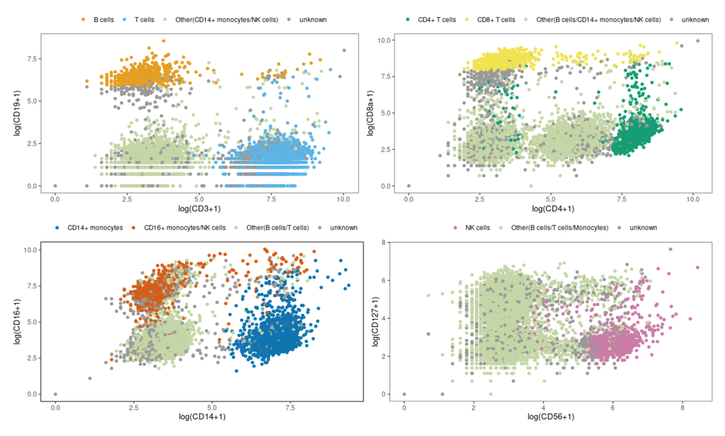

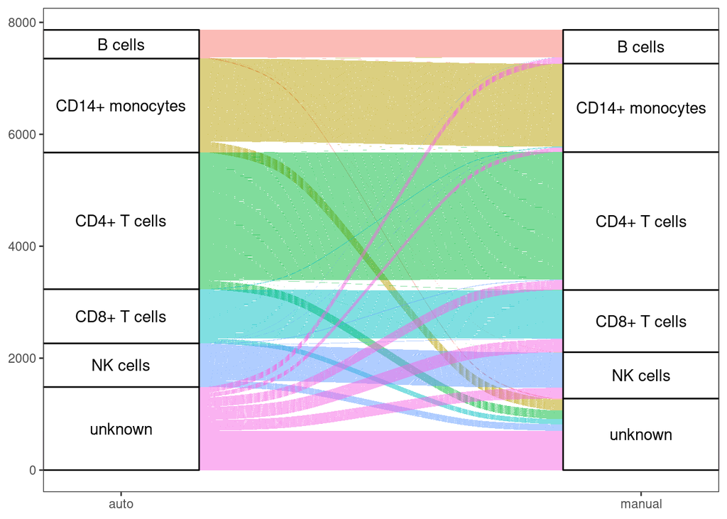

```r
library(ggalluvial)
comparison_plot = comparison %>% gather(key = "source", value = "class", pred, true)

ggplot(comparison,
       aes(axis1 = pred, axis2 = true)) +
  geom_alluvium(aes(fill = pred)) +
  geom_stratum(width = 0.3) +
  geom_text(stat = "stratum", aes(label = after_stat(stratum))) +
  scale_x_discrete(limits = c("auto", "manual"), expand = c(.05, .05)) +
  theme_test() + theme(legend.position = "none")
```

# Generalized function

The following function adds uncertainty to the gating results given by FLOCK. It directly uses the FLOCK analysis result as input. Users can specify the number of folds that they want the input dataset to be randomly divided into. For the cells in each fold, to predict their cell type identities(with uncertainties), cells from all the other folds are used as the training set for linear discriminant analysis, and the gating results by FLOCK will be used as the true labels. Users can also specify the cut-off value to divide between “confident” and “unknown” cells. A cell that is predicted to have a probability greater than the cut-off value to belong to a population will be “confidently” labeled as a cell from that population; otherwise, the cell is labeled as “unknown”. Even if there’s not sufficient biological background knowledge to annotate predicted cell populations as specific cell types, this function can still be applied.

```r
LDA_flock = function(data, nfolds = 5, cut_off = 0.9){

  if(nfolds <= 1)
    stop("nfolds should be greater than 1")
  if(cut_off <= 0 || cut_off >= 1)
    stop("cut_off value should be between 0 and 1")

  data = data %>%
  mutate(Folds = createFolds(Population, k = nfolds, list = F)) %>%
  mutate(id = 1:nrow(.))


  for (i in 1:nfolds) {
     lda.fit <- lda(Population ~ ., data = data %>% filter(Folds != i) %>%
                      dplyr::select(-id, -Folds))
     lda.pred = predict(lda.fit, newdata = data %>% filter(Folds == i) %>%
                          dplyr::select(-id, -Folds))
     pred_subset = data %>%
     filter(Folds == i) %>%
     dplyr::select(id) %>%
     bind_cols(lda.pred$posterior %>% as_tibble())

     if (i == 1)
         pred = pred_subset
     else
         pred = bind_rows(pred, pred_subset)
    }

  pred = pred %>%
     arrange(id) %>%
     dplyr::select(-id)

  map_class = function(x){
   if (max(x) > cut_off)
       return(sprintf("population %d", which.max(x)))
   else
       return("unknown")
   }

  data = data %>%
     mutate(class = apply(pred, 1, map_class)) %>%
    dplyr::select(id, class)

  return(data)
}
```

### Example of usage

```r
flock = read_csv("../Data/flock_result_auto.csv") #analysis results from FLOCK


output = LDA_flock(flock, nfolds = 5, cut_off = 0.95)
head(output) %>% knitr::kable()
```

| id | class |
| --- | --- |
| 1 | population 5 |
| 2 | unknown |
| 3 | population 5 |
| 4 | population 1 |
| 5 | population 1 |
| 6 | population 5 |

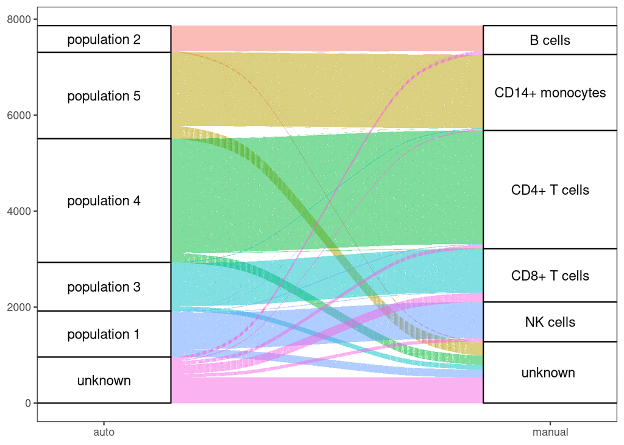

```r
load("~/FLOCK/Automatic Gating/Data/Truth_10X10k.rdata")
true_type = recode(true_type, `Dendritic cells` = "unknown", `CD16+ monocytes` = "unknown")
comparison = tibble(true = true_type, pred = output$class)

library(ggalluvial)

comparison %>%
  mutate(true = recode(true, unknown = "unknown ")) %>%
  mutate(pred = fct_relevel(pred,  "population 2", "population 5", "population 4", "population 3", "population 1", "unknown"), true = fct_relevel(true, "B cells", "CD14+ monocytes", "CD4+ T cells", "CD8+ T cells", "NK cells", "unknown ")) %>%
ggplot(aes(axis1 = pred, axis2 = true)) +
  geom_alluvium(aes(fill = pred)) +
  geom_stratum(width = 0.3) +
  geom_text(stat = "stratum", aes(label = after_stat(stratum))) +
  scale_x_discrete(limits = c("auto", "manual"), expand = c(.05, .05)) +
  theme_test() + theme(legend.position = "none")
```

# Reference

[1] Qian, Y. et al. (2010) Elucidation of seventeen human peripheral blood B-cell subsets and quantification of the tetanus response using a density-based method for the automated identification of cell populations in multidimensional flow cytometry data. Cytometry B Clin. Cytom. 78 (suppl. 1), S69–S82

[2] Aghaeepour, N., Nikolic, R., Hoos, H.H. & Brinkman, R.R. (2011) Rapid cell population identification in flow cytometry data. Cytometry A 79, 6–13

[3] Aghaeepour N, Finak G; FlowCAP Consortium, DREAM Consortium, Hoos H, Mosmann TR, et al. (2013) Critical assessment of automated flow cytometry data analysis techniques. Nat Methods 10(3):228–38. doi: 10.1038/nmeth.2365

[4] Verschoor CP, Lelic A, Bramson JL and Bowdish DME (2015) An introduction to automated flow cytometry gating tools and their implementation. Front. Immunol. 6:380. doi: 10.3389/fimmu.2015.00380